# btc_part1_draft.rmd

timothy leffel may31/2017

**work in progress, may31/2017**

- part1: quick description of idea, plot + validate twitter btc price strategy (*just twitter + external btc data*)
- part2: use monkeylearn classifiers to measure sentiment abt stuff, moving to btc topic (*introduce monkeylearn api*)
- part3: identify key dates, assess rel’ship btwn btc sentiment and price (*limitations of twitter api become obvious here*)

The use of twitter data for estimating public sentiment about issues can still be considered a fledgling-ish field. Here we assess the degree to which a fairly naive sentiment classifier can be used to predict the trajectory of the average bitcoin trading price, over time. The catch is that we’ll only use data publicly available via the twitter API. This is limiting in a few respects, chief among which is that targeting specific historical date ranges is basically impossible with only the standard twitter API tools (to my knowledge, at least). A scaled-up version of this strategy would ideally obtain user tweets from the twitter firehose…

linxe to put in final post:

- [the concept of a “twitter-driven” trading bot](https://thestack.com/world/2015/05/08/three-steps-to-building-a-twitter-driven-trading-bot/)
- documentation for `monkeylearn::` R package
- [twitter firehose vs api (and api’s in general)](https://brightplanet.com/2013/06/twitter-firehose-vs-twitter-api-whats-the-difference-and-why-should-you-care/)
- …

### 1. btc prices from twitter

#### set up twitter api

```r
# read in api keys and access tokens
keyz <- read.csv("../../../../keyz.csv", stringsAsFactors=FALSE)
# set up twitter auth -- call `setup_twitter_oauth()` w keys from `keyz`
setup_twitter_oauth(
  consumer_key    = keyz$value[keyz$auth_type=="twtr_api_key"],
  consumer_secret = keyz$value[keyz$auth_type=="twtr_api_sec"],
  access_token    = keyz$value[keyz$auth_type=="twtr_acc_tok"],
  access_secret   = keyz$value[keyz$auth_type=="twtr_acc_sec"]
)
```

```
## [1] "Using direct authentication"
```

#### get btc price tweets + clean them up

```r
# get tweets from user @bitcoinprice for maximum n (3200 as of may2017)

# @bitcoinprice
# The average price of Bitcoin across all exchanges is ...
dat <- userTimeline(user="bitcoinprice", n=3200, excludeReplies=TRUE) %>%
  twListToDF() %>%
  # PUT RENAMES HERE INSTEAD OF BELOW
  select(text, screenName, created, favoriteCount, retweetCount, isRetweet) %>%
  mutate(date=date(created), hour=hour(created)) %>%
  rename(data_source=screenName)
```

```r
# a tweet consists of "toss[1] + dddd.dd + toss[2]"
toss <- c("The average price of Bitcoin across all exchanges is ", " USD")

# check that all tweets are formulaic + as expected
if (!all(grepl(paste0(toss[1], "\\d*\\.?\\d*", toss[2]), dat$text))){
  message("careful -- tweets not as formulaic as they may seem! :/ ")
}

# if tweets are formulaic, just remove `toss` + extract price from `dat$tweet`
dat$price <- gsub(paste0(toss, collapse="|"), "", dat$text)

# check that we don't have any words/letters left before converting
if (sum(grepl("[a-z]", dat$price)) > 0){
  warning("careful -- some tweets were not in expected format! :o ")
}

# now convert to numeric
dat$price <- as.numeric(dat$price)

# PUT THIS AS A FILTER IN PIPE CHAIN ABOVE
# delete any retweets that could've crept in
dat <- dat[!dat$isRetweet, ]

# INTEGRATE THIS INTO PIPE CHAIN ABOVE
# convert date_time to nicer format [CHECK THAT MOVING FROM lt TO CT IS OKAY]
dat$date_time <- as.POSIXct(dat$created, tz="UTC")

# PUT THIS IN PIPE CHAIN ALSO
# get day of the week so we can look at weekly trends
dat$day <- weekdays(dat$date_time, abbreviate=TRUE)
dat$day <- factor(dat$day, levels=c("Mon","Tue","Wed","Thu","Fri","Sat","Sun"))
# "Monday","Tuesday","Wednesday","Thursday","Friday","Saturday","Sunday"

# notice that on 2017-03-14 15:00:03, the value is listed at $1.25
# inspecting the surrounding data suggests it's probably meant to be $1225.00.
# **exercise**: what does this suggest about how the bot works?
dat$price[dat$price==1.25] <- dat$price[dat$price==1.25] * 1000

# INTEGRATE THIS INTO PIPECHAIN ABOVE
# now cut the df to just the cols we want
dat <- dat[, c("data_source","created","date","hour","day","price")]
```

#### plot the data

```r
# what's our date range? (3200 hourly tweets so should be 3200/24 days ~ 4mo)
range(dat$date)
```

```
## [1] "2017-01-18" "2017-06-01"
```

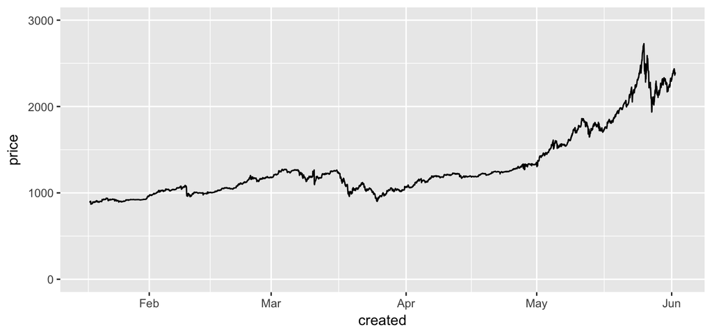

```r
# now make some plots!
ggplot(dat, aes(x=created, y=price)) +
  geom_line() + scale_y_continuous(limits=c(0, 3000))
```

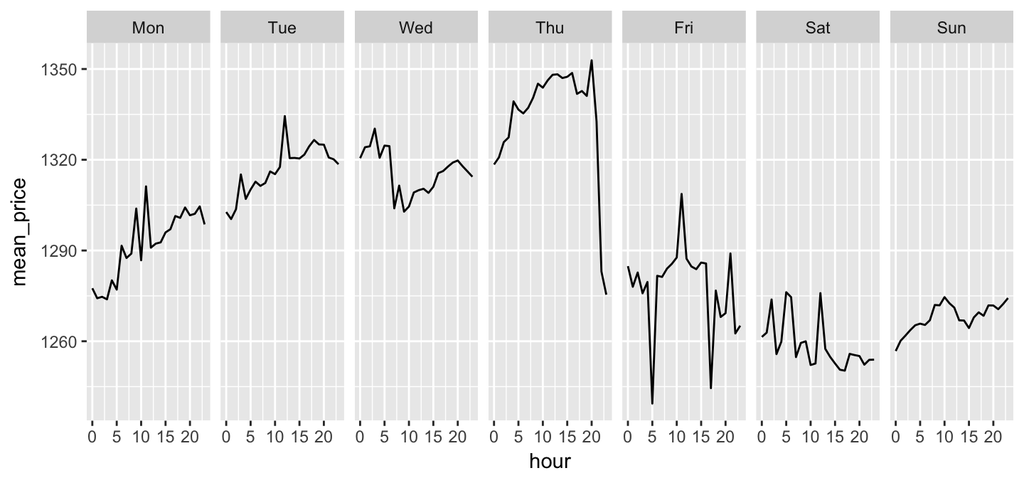

```r
pdat <- dat %>% select(day, hour, price) %>% group_by(day, hour) %>% summarize(
  mean_price = mean(price)
) %>% data.frame()

ggplot(pdat, aes(x=hour, y=mean_price)) +
  geom_line() +
  facet_wrap(~day, ncol=7)
```

#### inspect + validate accuracy on external data_source

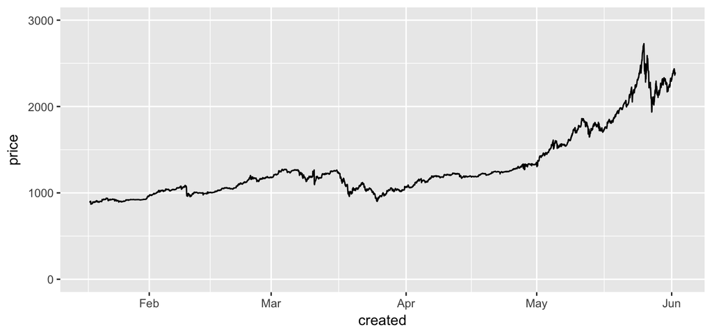

```r
### get external data now
bdat <- read.csv(
  "data/bitcoinity_data-price-volume.csv",
  col.names=c("date","price","volume"),
  colClasses=c("Date","numeric","numeric")
)
bdat$data_source <- "bitcoinity.org"

# the twitter data:
ggplot(dat, aes(x=created, y=price)) +
  geom_line() + scale_y_continuous(limits=c(0, 3000))
```

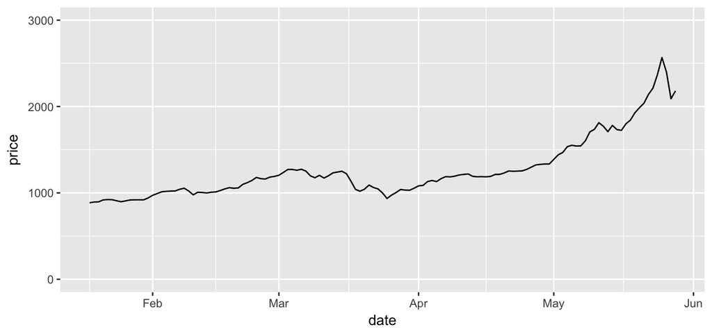

```r
# the external data, plotted on the same interval:
ggplot(bdat[bdat$date >= min(dat$date), ], aes(x=date, y=price)) +
  geom_line() + scale_y_continuous(limits=c(0, 3000))
```

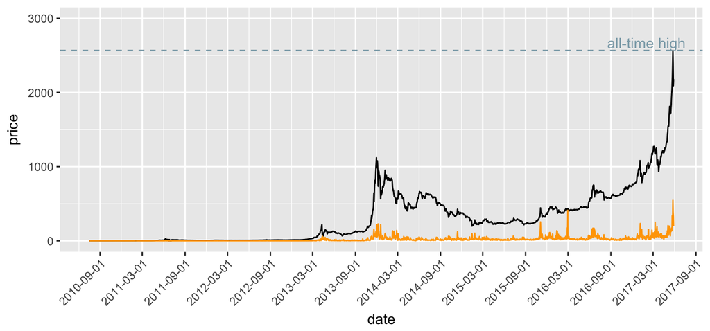

```r
# the external data, plotted on the whole lifetime of btc:
ggplot(bdat, aes(x=date, y=price)) +
  geom_line() + scale_y_continuous(limits=c(0, 3000)) +
  geom_line(aes(x=date, y=volume/1e6), color="orange") +
  scale_x_date(date_breaks="6 months") +
  geom_hline(yintercept=max(bdat$price), color="#8aa8b5", linetype="dashed") +
  annotate(geom="text", x=as.Date("2017-02-01"), y=max(bdat$price)+100,
           color="#8aa8b5", label="all-time high") +
  theme(axis.text.x=element_text(angle=45, vjust=1, hjust=1))
```

```r
# want to merge twitter data with bitcoinity data
# first need to aggregate twitter data to the day-level
tdat_simple <- dat %>%
  mutate(date=as.character(date)) %>%
  select(data_source, date, price) %>%
  group_by(data_source, date) %>% summarize(
  price = mean(price, na.rm=TRUE)
) %>% data.frame()

bdat_simple <- bdat %>%
  filter(date >= min(dat$date)) %>%
  select(data_source, date, price) %>%
  mutate(date=as.character(date)) %>%
  data.frame()

head(tdat_simple, 2); head(bdat_simple, 2)
```

```
##    data_source       date    price
## 1 bitcoinprice 2017-01-18 885.6124
## 2 bitcoinprice 2017-01-19 895.8383
```

```
##      data_source       date    price
## 1 bitcoinity.org 2017-01-18 886.0109
## 2 bitcoinity.org 2017-01-19 894.0286
```

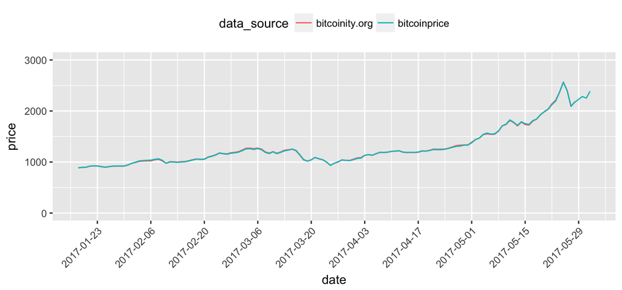

```r
merged      <- rbind(tdat_simple, bdat_simple)
merged$date <- as.Date(merged$date)


ggplot(merged, aes(x=date, y=price, group=data_source, color=data_source)) +
  geom_line() +
  scale_y_continuous(limits=c(0, 3000)) +
  scale_x_date(date_breaks="2 weeks") +
  theme(axis.text.x=element_text(angle=45, vjust=1, hjust=1)) +
  theme(legend.position="top")
```

```r
# yep, checks out...
```